# PROJET MACHINE LEARNING

## 4.4 Méthode ensembliste : le boosting - XGBOOST

Une autre méthode que nous pouvons utiliser est le XGBOOST (Extreme Gradient Boosting) ; c’est une méthode similaire au gradient boosting mais plus efficace. Elle combine des algorithmes d’apprentissage des arbres et des modèles linéaires. En plus, elle permet de faire des calculs parallèles sur une seule machine, ce qui la rend très rapide.

Avec cette méthode nous pouvons faire des régressions, classifications et rankings. Cependant il y a plusieurs paramètres qui doivent être contrôlés afin d’optimiser le modèle.

**Préparation des données**

Avant d’utiliser l’algorithme xgboost nous devons preparer les données, XGBoost fonctionne uniquement avec des vecteurs numériques. C’est-à-dire, nous devons transformer toutes nos variables utiliser en nombre, dont sex, categorie, reg et city.type.

1- Transformation des Variables vecteurs numériques

Nous allons utiliser le one hot encoding pour créer des variables “dummy” et ainsi convertir les variables en numériques. Par exemple, pour le genre il fera deux variables : SexFemale et SexMale, et donnera la valeur de 1 sur la colonne SexFemale quand l’individu est de sexe féminin et zéro dans la colonne SexMale.

2 - Séparer la variable à prédire

La deuxième étape consiste à séparer la variable cible du reste de la matrice.

3 - Dmatrice

La troisième étape consiste à convertir nos données en format Dmatrice. Cette étape n’est pas nécessaire, mais elle va faire que l’entrainement soit plus rapide, et c’est obligatoire si on souhaite utiliser plusieurs coeurs. Nous utilisons pour le faire la fonction xgb.DMatrix.

**Entrainer le modèle**

Afin d’entrainer notre modèle, Xgboost a besoin de connaître :

1- Les données à utiliser pour l’entrainement, notre dmatrix dtrain

2- Le nombre de tours d’entrainement. Cela signifie le nombre de fois où nous allons améliorer notre modèle en ajoutant des modèles supplémentaires.

3- La fonction objective. Nous allons utiliser “binary:logistic”, qui est la régression logistique pour la classification binaire. Par défaut, xgboost effectue une régression linéaire.

**Prédiction avec xgboost**

Nous pouvons maintenant lancer notre entrainement avec la fonction classique *predict*.

```
## [1] "erreur de test = 7.336 %"
```

**Matrice de confusion**

Regardons maintenant la matrice de confusion:

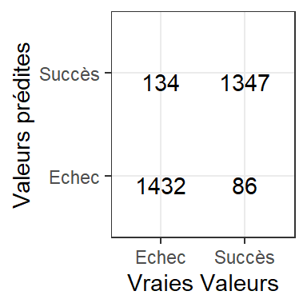

**Améliorer notre modèle**

Nous pouvons modifier quelques paramètres pour améliorer notre modèle :

- **max.depth** = 6 la profondeur maximale de chaque arbre de décision
- **nrounds** = 100 nombre maximum d’itérations de boost

```
## [1] "erreur de test = 5.068 %"
```

Uniquement avec deux paramètres, notre erreur a baissé. Cependant nous avons d’autres paramètres qui peuvent être ajustés, comme :

- **eta** = Taille de chaque étape de boosting
- **nfold** = l’ensemble de données d’origine est partitionné de manière aléatoire en nfold sous-échantillons de taille égale
- **nthread**= nombre de threads utilisés dans la formation, s’ils ne sont pas définis, tous les threads sont utilisés

Par rapport aux résultats obtenus, nous n’allons pas modifier ces paramètres

**Importance des variables**

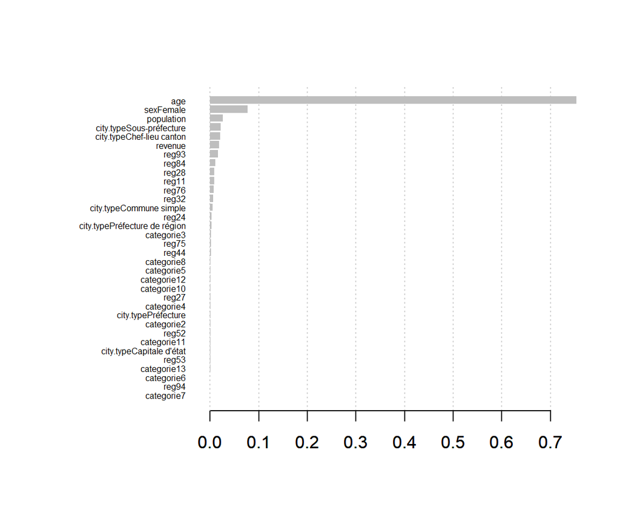

Comme les autres modèles, l’âge est la variable la plus pertinente ; il apparait aussi que la modalité “sexe - féminin” est influente pour la construction de l’arbre XGboost.

**Courbe ROC et AUC**

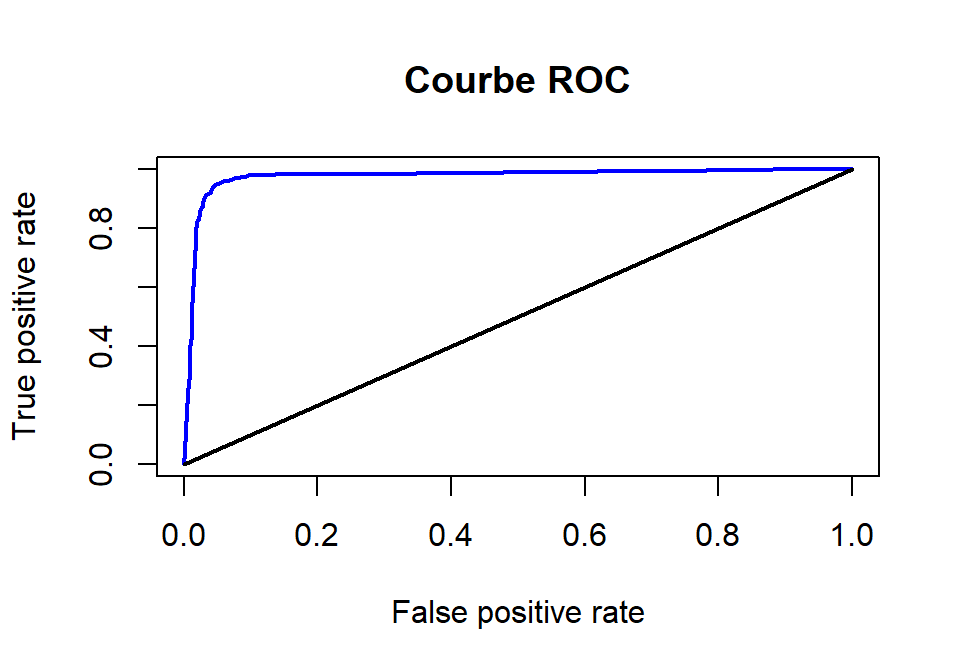

**Avec un modèle de xgboost, on obtient un AUC est de 0.9734**

## 4.5 En conclusion

Les résultats des différentes méthodes testées sont les suivants :

| Méthodes testées | AUC | Erreur de prédiction |
| --- | --- | --- |
| Regression logistique | 0.8895 | 16.739 % |
| Arbre de décision | 0.9251 | 7.503 % |
| Forêt aléatoire | 0.9128 | 5.803 % |
| Boosting | 0.9734 | 5.068 % |

**ROC**

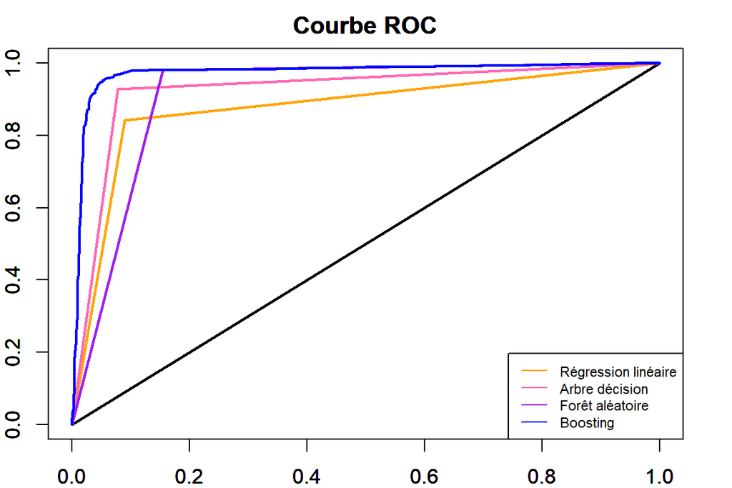

**La modélisation de la variable cible par la méthode Xgboost apporte ici le meilleur résultat.**  
En effet, l’AUC du boosting est le plus proche de 1 (0.9734), ce qui s’illustre par une courbe de ROC qui tend le plus rapidement vers 1 (graphiquement: la plus proche du coin supérieur gauche).

Nous choisissons donc de faire la prédiction à partir du modèle de boosting.

# 5 Annexes

## 5.1 Annexe - Données Manquantes

Afin d’avoir plus d’informations sur les données manquantes, nous allons utiliser le graphique “Marginplot” et observé chaque variable avec la variable *revenue*.

Dans ce graphique, les points sans valeurs manquantes apparaissent dans le scatterplot. On observe qu’il manque des valeurs pour tous les âges (ligne rouge verticale, de 15 à 100 ans). Nous avons également les boxplots des distributions des valeurs : en rouge quand la valeur est manquante et en bleu quand la valeur est observée.

**Le revenu et l’âge**

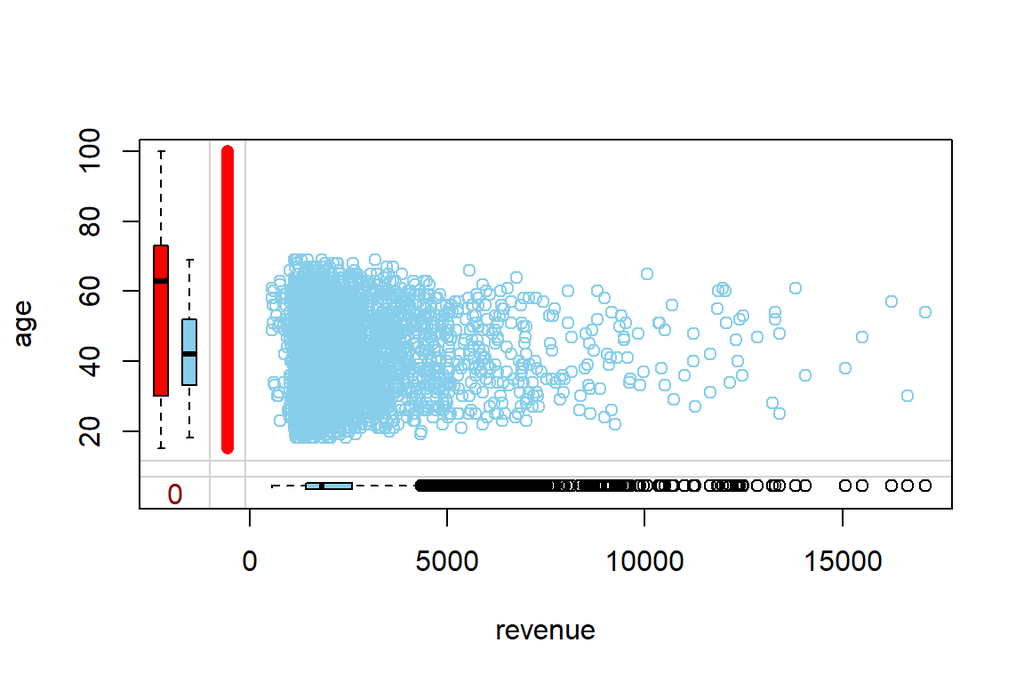

Les valeurs des revenus sont observées uniquement sur la tranche d’âge des 18 ans-69 ans, qui correspond à la période d’activité professionnelle.

**Le revenu et la catégorie socio-professionnelle**

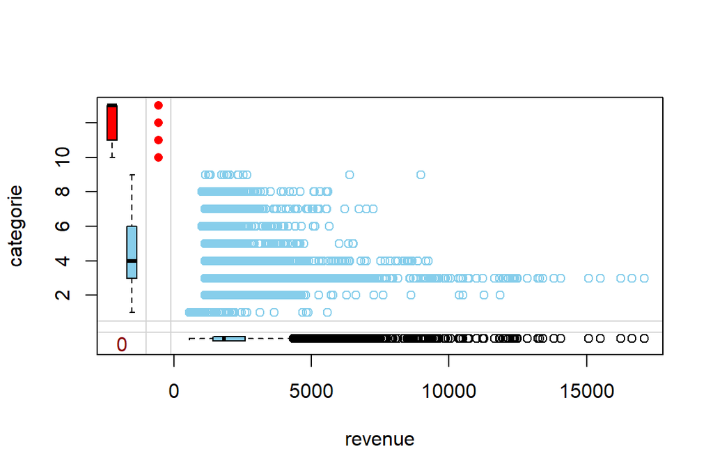

Selon le graphique, il y a que 4 catégories sans revenu (10, 11, 12 et 13) : étudiants, chômeurs, inactifs et retraités. Sur le reste des catégories, nous ne trouverons pas des données absentes.

## 5.2 Annexe - Analyse exploratoire

Ce graphique montre que les variables qui vont beaucoup influencer notre prédiction seront surement l’age et la categorie socio-professionnelle.

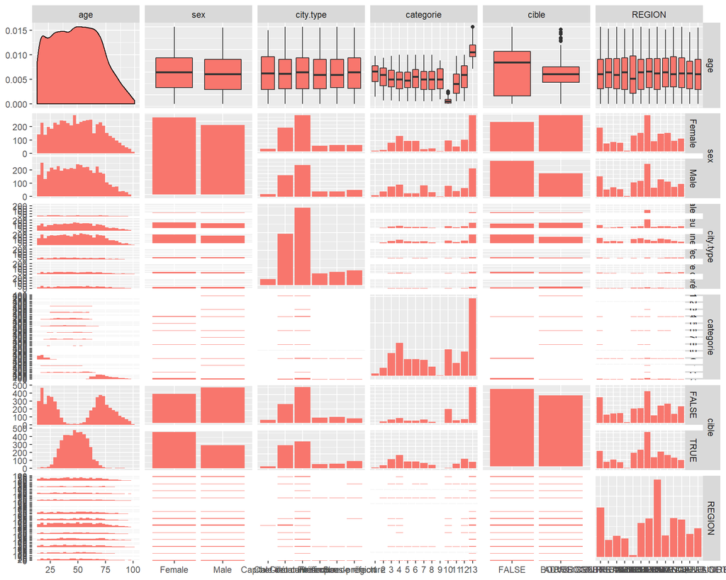

## 5.3 Annexe - Regression linéaire - Graphique des résidus

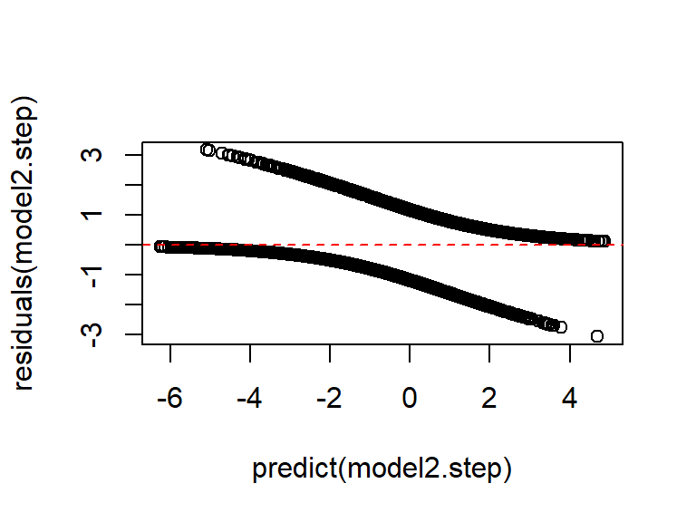

## 5.4 Annexe - XGBOOST - Graphique de l’arbre

[interactive chart not shown]

Le haut de l’arbre se trouve à gauche et le bas de l’arbre à droite. Pour les fonctionnalités, le nombre à côté de celui-ci est “qualité”, ce qui permet d’indiquer l’importance de cette fonctionnalité dans tous les arbres. Une qualité supérieure signifie qu’une fonctionnalité était plus importante. .

Pour les feuilles, le nombre à côté est la valeur moyenne que le modèle a renvoyée pour tous les arbres si une certaine observation aboutissait à cette feuille. Parce que nous utilisons un modèle logistique ici, il nous indique les log-odds plutôt que la probabilité.